# Overview

```r
library(ggplot2)
library(reshape)
library(gplots)
library(edgeR)
library(CHBUtils)
library(pheatmap)

baseDir = "/home/mistrm82/R/sharpePD1_rnaseq"
project_summary = file.path(baseDir, "project-summary.csv")
counts_file = file.path(baseDir, "combined.counts")
cbPalette <- c("#999999", "#E69F00", "#56B4E9", "#009E73", "#F0E442", "#0072B2",
    "#D55E00", "#CC79A7")
summarydata = data.frame(read.table(project_summary, header = TRUE, sep = ","),
    row.names = "Name", check.rows = FALSE)
summarydata$Name = rownames(summarydata)
summarydata = summarydata[order(summarydata$Name), ]
counts = read.table(counts_file, header = TRUE, row.names = "id", check.names = FALSE)
counts = counts[, order(colnames(counts))]

# Load metadata
meta = read.csv(file.path(baseDir, "meta/sharpePD1_project.csv"), row.names = 1)
meta = meta[order(rownames(meta)), ]
rows <- sapply(row.names(meta), function(x) {
    strsplit(x, split = ".", fixed = T)[[1]][1]
})
row.names(meta) <- unname(rows)


# this is a list of all non user-supplied metadata columns that could appear
known_columns = c("Name", "X.GC", "Exonic.Rate", "Sequences.flagged.as.poor.quality",
    "rRNA.rate", "Fragment.Length.Mean", "Intronic.Rate", "Intergenic.Rate",
    "Mapping.Rate", "Quality.format", "Duplication.Rate.of.Mapped", "Mapped",
    "rRNA", "Sequence.length", "Transcripts.Detected", "Mean.Per.Base.Cov.",
    "Genes.Detected", "Unique.Starts.Per.Read", "unique_starts_per_read", "complexity",
    "X5.3.bias")
```

# Quality control metrics

## Mapped reads

The number of mapped reads are quite low across the board (maximum ~ 6 millions reads). There are five samples that are on the very low range (less than 2 million reads), and these samples correspond to the Cre- PD1- sample group (the 6th sample from this group is also quite low with just over 2million reads). The Cre+ PD1+ samples fall in the higher range of mapped reads; which are the samples we are most interested in for our comparison.

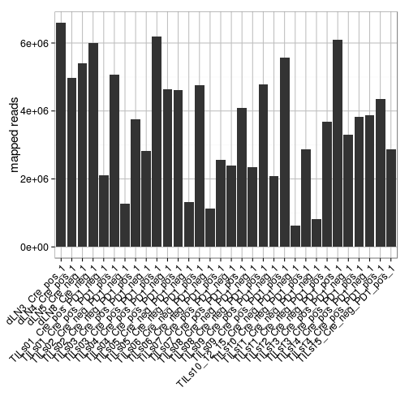

```r
ggplot(summarydata, aes(x = Name, y = Mapped)) + theme_bw(base_size = 10) +
    theme(panel.grid.major = element_line(size = 0.5, color = "grey"), axis.text.x = element_text(angle = 45,
        hjust = 1)) + geom_bar(stat = "identity") + ylab("mapped reads") + xlab("") +
    theme(axis.title = element_text(size = rel(1.5)), axis.text = element_text(size = rel(1.25)))
```

## Genomic mapping rate

A good mapping rate across the board.

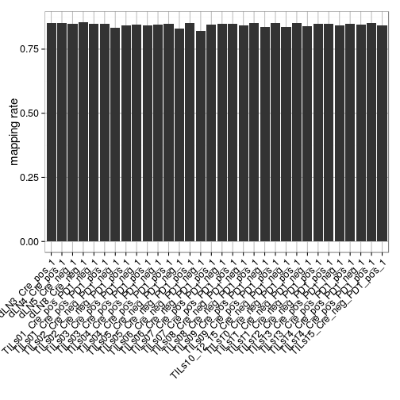

```r
ggplot(summarydata, aes(x = Name, y = Mapping.Rate)) + ylab("mapping rate") +
    xlab("") + theme_bw(base_size = 10) + geom_bar(stat = "identity") + theme(panel.grid.major = element_line(size = 0.5,
    color = "grey"), axis.text.x = element_text(angle = 45, hjust = 1), axis.title = element_text(size = rel(1.5)),
    axis.text = element_text(size = rel(1.25)))
```

## Unique mapping rate

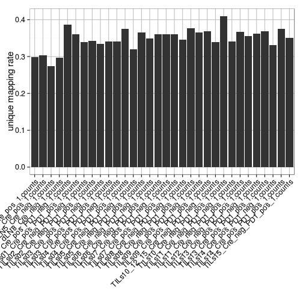

```r
dd = data.frame(Name = names(counts), Unique = colSums(counts), Mapped = summarydata[,
    "Mapped"])
ggplot(dd, aes(x = Name, y = Unique/Mapped)) + geom_bar(stat = "identity") +
    ylab("unique mapping rate") + xlab("") + theme_bw(base_size = 10) + theme(panel.grid.major = element_line(size = 0.5,
    color = "grey"), axis.text.x = element_text(angle = 45, hjust = 1), axis.title = element_text(size = rel(1.5)),
    axis.text = element_text(size = rel(1.25)))
```

## Number of genes detected

Usually, for mouse we observe ~15k genes to be detected - here we see half that (and in some samples, less). This is in line with the low exonic mapping rate that we observe (see below).

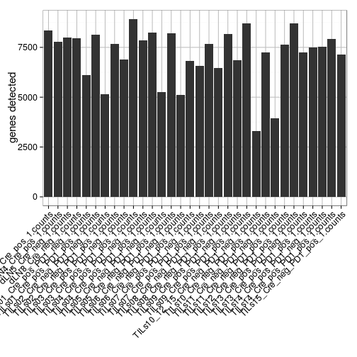

```r
dd = data.frame(Name = names(counts), Genes.Detected = colSums(counts > 0))
ggplot(dd, aes(x = Name, y = Genes.Detected)) + geom_bar(stat = "identity") +
    theme_bw(base_size = 10) + theme(panel.grid.major = element_line(size = 0.5,
    color = "grey"), axis.text.x = element_text(angle = 45, hjust = 1), axis.title = element_text(size = rel(1.5)),
    axis.text = element_text(size = rel(1.25))) + ylab("genes detected") + xlab("")
```

## Gene detection saturation

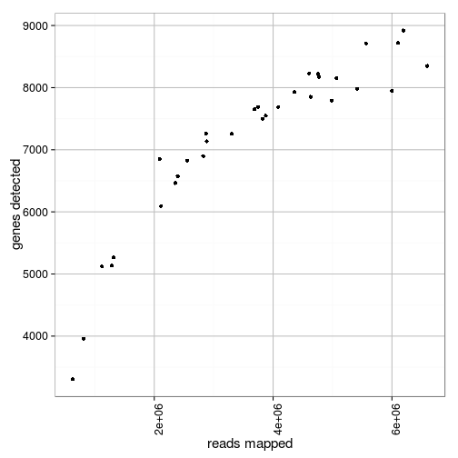

```r
dd = data.frame(Mapped = summarydata$Mapped, Genes.Detected = colSums(counts >
    0))
ggplot(dd, aes(x = Mapped, y = Genes.Detected)) + geom_point() + theme_bw(base_size = 10) +
    theme(panel.grid.major = element_line(size = 0.5, color = "grey"), axis.text.x = element_text(angle = 90),
        axis.title = element_text(size = rel(1.5)), axis.text = element_text(size = rel(1.25))) +
    ylab("genes detected") + xlab("reads mapped")
```

## Exonic mapping rate

The next two figures gives us insight as to where reads are mapping. There are an unusually low number of reads mapping to exonic regions (< 50%) and higher than normally observed mapping to intergenic (~40%; see below). Usually this would mean possible genomic DNA contamination and/or pre-mRNA.

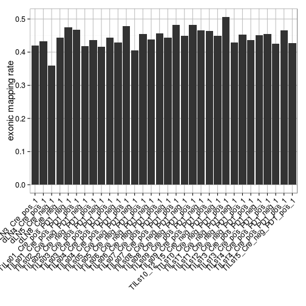

```r
ggplot(summarydata, aes(x = Name, y = Exonic.Rate)) + geom_bar(stat = "identity") +
    theme_bw(base_size = 10) + theme(panel.grid.major = element_line(size = 0.5,
    color = "grey"), axis.text.x = element_text(angle = 45, hjust = 1), axis.title = element_text(size = rel(1.5)),
    axis.text = element_text(size = rel(1.25))) + ylab("exonic mapping rate") +
    xlab("")
```

## Intergenic mapping rate

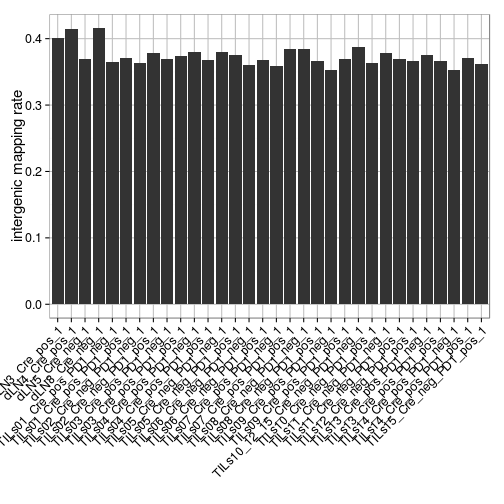

```r
ggplot(summarydata, aes(x = Name, y = Intergenic.Rate)) + geom_bar(stat = "identity") +
    theme_bw(base_size = 10) + theme(panel.grid.major = element_line(size = 0.5,
    color = "grey"), axis.text.x = element_text(angle = 45, hjust = 1), axis.title = element_text(size = rel(1.5)),
    axis.text = element_text(size = rel(1.25))) + ylab("intergenic mapping rate") +
    xlab("")
```

## rRNA mapping rate

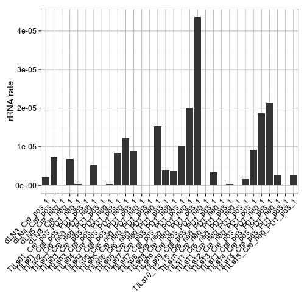

```r
ggplot(summarydata, aes(x = Name, y = rRNA.rate)) + geom_bar(stat = "identity") +
    theme_bw(base_size = 10) + theme(panel.grid.major = element_line(size = 0.5,
    color = "grey"), axis.text.x = element_text(angle = 45, hjust = 1), axis.title = element_text(size = rel(1.5)),
    axis.text = element_text(size = rel(1.25))) + ylab("rRNA rate") + xlab("")
```

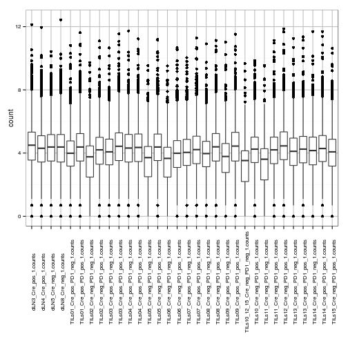

```r
melted = melt(counts)
colnames(melted) = c("sample", "count")
melted$sample = factor(melted$sample)
melted$sample = reorder(melted$sample, colnames(counts))
melted$count = log(melted$count)
ggplot(melted, aes(x = sample, y = count)) + geom_boxplot() + theme_bw(base_size = 10) +
    theme(panel.grid.major = element_line(size = 0.5, color = "grey"), axis.text.x = element_text(angle = 90)) +
    xlab("")
```

Trimmed mean of M-values (TMM) normalization is described [here](http://genomebiology.com/2010/11/3/R25)

Robinson, M. D., & Oshlack, A. (2010). A scaling normalization method for differential expression analysis of RNA-seq data. Genome Biology, 11(3). doi:10.1186/gb-2010-11-3-r25

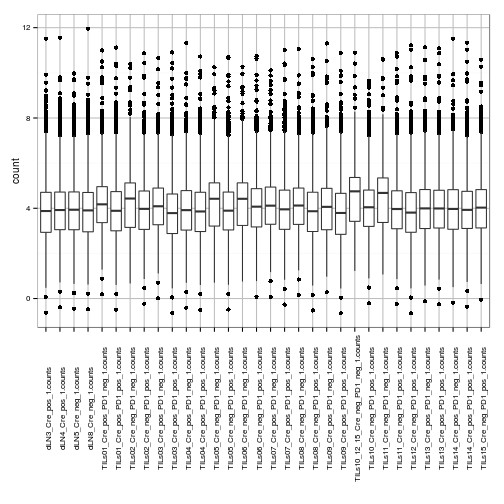

```r
y = DGEList(counts = counts)
y = calcNormFactors(y)
normalized_counts = cpm(y, normalized.lib.sizes = TRUE)
melted = melt(normalized_counts)
colnames(melted) = c("gene", "sample", "count")
melted$sample = factor(melted$sample)
melted$sample = reorder(melted$sample, colnames(counts))
melted$count = log(melted$count)
ggplot(melted, aes(x = sample, y = count)) + geom_boxplot() + theme_bw(base_size = 10) +
    theme(panel.grid.major = element_line(size = 0.5, color = "grey"), axis.text.x = element_text(angle = 90)) +
    xlab("")
```

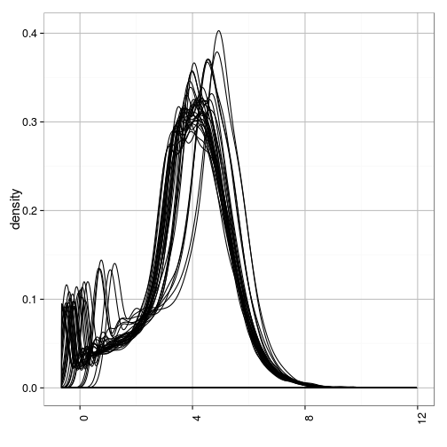

```r
ggplot(melted, aes(x = count, group = sample)) + geom_density() + theme_bw(base_size = 10) +
    theme(panel.grid.major = element_line(size = 0.5, color = "grey"), axis.text.x = element_text(angle = 90),
        axis.title = element_text(size = rel(1.5)), axis.text = element_text(size = rel(1.25))) +
    xlab("")
```

## Correlation (Pearson) heatmap of TMM-normalized counts

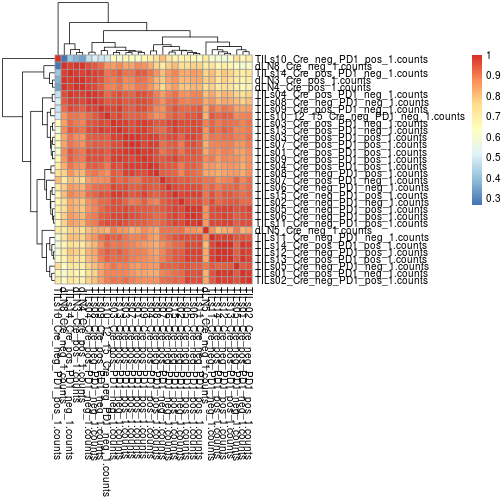

```r
heatmap_fn(cor(normalized_counts, method = "pearson"))
```

## Correlation (Spearman) heatmap of TMM-normalized counts

The two outlier samples correspond to samples that have less than 1 million reads mapped.

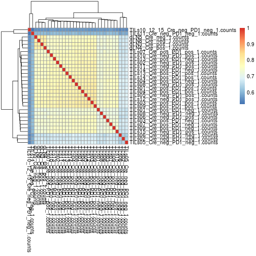

```r
heatmap_fn(cor(normalized_counts, method = "spearman"))
```

## MDS plot of TMM-normalized counts

There is no clear segregation of samples by group.

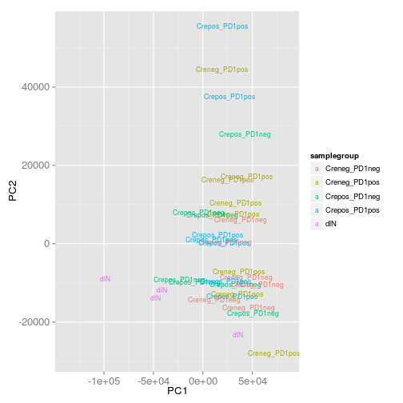

## Heatmap of top 30 most expressed genes

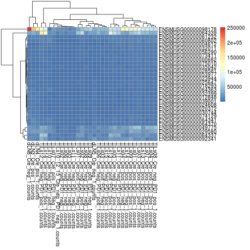

```r
select = order(rowMeans(counts), decreasing = TRUE)[1:30]
heatmap_fn(counts[select, ])
```

Styled with knitrBootstrap